# Projektarbeit Stefan Flachsbarth & Martin Haug Teil 4 - Visualisieren Wahl- und Strukturdaten

Analyse von Wahlergebnissen, Strukturdaten und Presseberichterstattung Bundestagswahlen im Zeitraum 1990 - 2017

Stefan Flachsbarth, Martin Haug

2019-10-22

## 5. Visualisierung der Wahl- und Strukturdaten

#### Laden der benötigten R-Pakete

```r
library(dplyr)
library(readxl)
library(readr)
library(tidyverse)
library(DBI)
library(fs)
library(rstudioapi)
library(ggplot2)
library(reshape2)
```

### 5.1. Laden der Daten aus der SQL-Datenbank

```r
# Definition einer Funktion, um die Daten in die SQL-Datenbank zu schreiben
ReadMyData <- function(table_name, table_content) {
  # Verbindung initialisieren
  con <- dbConnect(RPostgreSQL::PostgreSQL(),
    host = 'hdm-sql.think-data.de',
    dbname = 'postgres',
    user = 'postgres',
    password = '%%CENSORED%%'
    # Der richtige Weg, um auf sichere Weise das Passwort abzufragen
    # password = rstudioapi::askForPassword("Database password")
    )

  # Lesen der geschriebenen Daten
  return(dbReadTable(con, table_name))

  # Verbindung lösen
  dbDisconnect(con)
}


# Definieren einer Funktion, um die deutschen Umlaute korrekt anzuzeigen
set_utf8 <- function(x) {
  # Auf alle Spalten anwenden, welche Text enthalten
  chr <- sapply(x, is.character)
  # Iterieren durch alle Textelemente in der Saple
  x[, chr] <- lapply(x[, chr, drop = FALSE], `Encoding<-`, "UTF-8")
  # Natürlich auch auf den Spaltennamen
  Encoding(names(x)) <- "UTF-8"
  # Zurückgeben
  return(x)
}

btw2017 <- ReadMyData("dfin_2017", output)
btw2017 <- set_utf8(btw2017)
head(btw2017, 5)
```

```
  X WKRNR                      WKRNAME         Bundesland Wahljahr
1 1     1        Flensburg – Schleswig Schleswig-Holstein     2017
2 2     2 Nordfriesland – Dithmarschen Schleswig-Holstein     2017
3 3     3                    Steinburg Schleswig-Holstein     2017
4 4     4        Rendsburg-Eckernförde Schleswig-Holstein     2017
5 5     5                         Kiel Schleswig-Holstein     2017
  Wahlbeteiligung UNION1 UNION2 UNIONPZ  SPD1  SPD2 SPDPZ  LIN1  LIN2
1            0.75  68120  58320    0.34 47711 40388  0.23 12144 14002
2            0.75  62256  52928    0.38 34685 31120  0.22  7102  8589
3            0.75  54812  47366    0.36 34219 29756  0.23  7176  8732
4            0.78  66625  56585    0.36 45070 35766  0.23  8074  9962
5            0.75  46560  40736    0.27 46991 36208  0.24 11114 15546
  LINPZ  GRU1  GRU2 GRUPZ  FDP1  FDP2 FDPPZ  AFD1  AFD2 AFDPZ  CDU1  CDU2
1  0.08 17911 22304  0.13 11147 18955  0.11 10583 11653  0.07 68120 58320
2  0.06 13026 15144  0.11 11105 18050  0.13  8117  9030  0.06 62256 52928
3  0.07  8791 12960  0.10 14440 17298  0.13 10006 11180  0.08 54812 47366
4  0.06 13978 19337  0.12 10077 19071  0.12 10656 11578  0.07 66625 56585
5  0.10 21743 26143  0.17 11363 17804  0.12  9283 10504  0.07 46560 40736
  CDUPZ CSU1 CSU2 CSUPZ    WB1     W1 UNG1 UNG2  GUEL1  GUEL2 LANDABK
1  0.34    0    0     0 228471 171914 1596 1449 170318 170465      SH
2  0.38    0    0     0 186568 139194 1297 1123 137897 138071      SH
3  0.36    0    0     0 176636 132017 1134 1139 130883 130878      SH
4  0.36    0    0     0 200831 157354 1252 1087 156102 156267      SH
5  0.27    0    0     0 204650 153273 1594 1204 151679 152069      SH
  Check
1  0.96
2  0.96
3  0.97
4  0.96
5  0.97
```

### 5.2. Beantwortung einiger konkreter Fragestellungen mit Hilfe der Wahldaten aus der PostgreSQL-Datenbank

#### Frage 1 - Welche Ergebnisse konnte die CSU bei der Bundestagswahl 2017 in den bayerischen Wahlkreisen erzielen? (Zweitstimmenanteile)

```r
# Extraktion der für die Analyse benötigten Daten aus dem Datensatz 'btw2017'
btw2017 <- select(btw2017, -X)
bayerncsu2017 <- btw2017%>%
  filter(LANDABK=="BY")%>%
  select(WKRNAME, CSUPZ)

# Überprüfung der Datentypen und des Ergebnisses
glimpse(bayerncsu2017)
```

```
Observations: 46
Variables: 2
$ WKRNAME <chr> "Altötting", "Erding – Ebersberg", "Freising", "Fürste...
$ CSUPZ   <dbl> 0.44, 0.39, 0.39, 0.40, 0.41, 0.29, 0.31, 0.30, 0.30, ...
```

##### Visualisierung der Ergebnisse mit ggplot

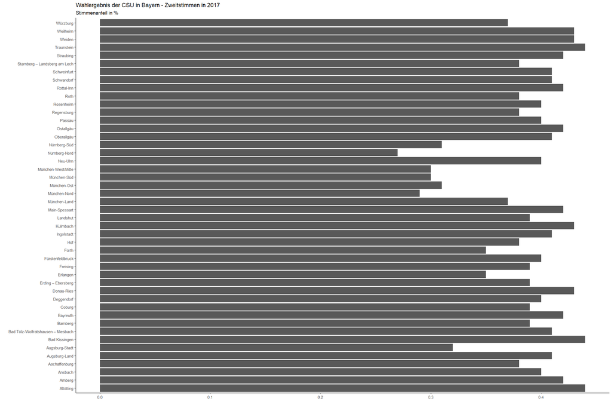

```r
# Visualisierung mit Hilfe eines horizontalen Barcharts
ggplot(bayerncsu2017, aes(x=WKRNAME, y=CSUPZ, sort(CSUPZ, descending=TRUE))) +
  geom_col() +
  coord_flip() +
  theme_classic(base_size=7) +
  ggtitle("Wahlergebnis der CSU in Bayern - Zweitstimmen in 2017") +
  labs(title="Wahlergebnis der CSU in Bayern - Zweitstimmen in 2017", subtitle="Stimmenanteil in %", x="", y="")
```

#### Frage 2 - Welcher Kandidat hat im Wahlkreis Stuttgart das Direktmandat geholt?

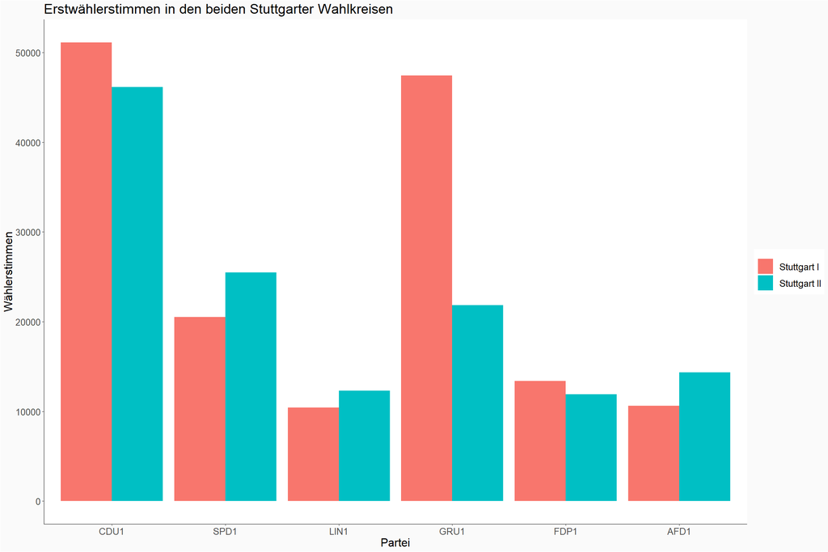

```r
# Extrahieren der benötigten Daten aus dem Datensatz 'btw2017'
stuttgart1 <- btw2017%>%
  filter(WKRNR=="258")%>%
  select(WKRNAME, CDU1, SPD1, LIN1, GRU1, FDP1, AFD1)
stuttgart2 <- btw2017%>%
  filter(WKRNR=="259")%>%
  select(WKRNAME, CDU1, SPD1, LIN1, GRU1, FDP1, AFD1)

# Zusammenführen der beiden Stuttgarter Wahlkreise in einen Datensatz
stuttgart <- bind_rows(stuttgart1, stuttgart2)

# Umstrukturierung der Datentabelle
stuttgart.long<-melt(stuttgart,id.vars="WKRNAME")

# Visualisierung der Ergebnisse in Form eines Barcharts
ggplot(stuttgart.long, aes(x=variable,y=value,fill=factor(WKRNAME)))+
  geom_bar(stat="identity",position="dodge")+
  scale_fill_discrete(name="WKRNAME",
                      breaks=c("Stuttgart I", "Stuttgart II"),
                      labels=c("Stuttgart I", "Stuttgart II"))+
  xlab("Partei")+ylab("Wählerstimmen")+
  theme_classic(base_size=7) +
  labs(title="Erstwählerstimmen in den beiden Stuttgarter Wahlkreisen") +
  theme(text = element_text(size=12),
        plot.background = element_rect(fill = "#FAFAFA"),
        panel.grid.major = element_blank(),
        panel.grid.minor = element_blank(),
        legend.title = element_blank())
```

#### Interpretation

Aus der Visualisierung lässt sich erkennen, dass sich im **Wahlkreis Stuttgart I der Kandidat der CDU mit etwas über 50.000 Stimmen** und einem knappen Vorsprung vor dem Kandidaten der Grünen (knapp unter 50.000 Stimmen) durchsetzen konnte. Der **Wahlkreis Stuttgart II ging ebenfalls an den Kandidaten der CDU**, hier jedoch mit einem deutlichen Vorsprung vor dem zweitplatzierten Kandidaten der SPD.

#### Frage 3 - Wie haben sich die Ergebnisse der Parteien in Ostdeutschland im Zeitraum 1990- 2017 entwickelt?

```r
# Extrahieren der benötigten Daten aus dem Datensatz 'btw2027', Einfügen einen neuen Spalte 'OstWest'
Ost2017 <- btw2017%>%
  mutate(OstWest = ifelse(LANDABK %in% c("MV", "BB", "SN", "TH", "ST"), "Ost", "West"))%>%
  filter(OstWest=="Ost")%>%
  select(Wahljahr, WKRNAME, LANDABK, W1, CDU2, SPD2, LIN2, GRU2, FDP2, AFD2, OstWest)%>%
  mutate(CDUPZ = round(sum(CDU2)/sum(W1), 2))%>%
  mutate(SPDPZ = round(sum(SPD2)/sum(W1), 2))%>%
  mutate(LINPZ = round(sum(LIN2)/sum(W1), 2))%>%
  mutate(GRUPZ = round(sum(GRU2)/sum(W1), 2))%>%
  mutate(FDPPZ = round(sum(FDP2)/sum(W1), 2))%>%
  mutate(AFDPZ = round(sum(AFD2)/sum(W1), 2))
head(Ost2017, 5)
```

```
  Wahljahr                        WKRNAME LANDABK     W1  CDU2  SPD2  LIN2
1     2017 Schwerin – Ludwigslust-Parchim      MV 157071 51083 28947 25929
2     2017            Nordwestmecklenburg      MV 146768 48841 25029 24409
3     2017                        Rostock      MV 164016 49433 25650 33575
4     2017               Vorpommern-Rügen      MV 169528 55110 20405 30107
5     2017          Vorpommern-Greifswald      MV 156965 51789 19064 27246
   GRU2  FDP2  AFD2 OstWest CDUPZ SPDPZ LINPZ GRUPZ FDPPZ AFDPZ
1  6606  9879 25692     Ost  0.28  0.14  0.17  0.04  0.07  0.22
2  5521  9008 25688     Ost  0.28  0.14  0.17  0.04  0.07  0.22
3 10229 10661 25171     Ost  0.28  0.14  0.17  0.04  0.07  0.22
4  8498 11490 32881     Ost  0.28  0.14  0.17  0.04  0.07  0.22
5  4068  8659 35595     Ost  0.28  0.14  0.17  0.04  0.07  0.22
```

#### Extrahieren der benötigten Daten für die Jahre 1990 bis 2013, Einfügen einen neuen Spalte ‘OstWest’

```r
# Wahl 2013
btw2013 <- ReadMyData("dfin_2013", output)
btw2013 <- set_utf8(btw2013)
Ost2013 <- btw2013%>%
  mutate(OstWest = ifelse(LANDABK %in% c("MV", "BB", "SN", "TH", "ST"), "Ost", "West"))%>%
  filter(OstWest=="Ost")%>%
  select(Wahljahr, WKRNAME, LANDABK, W1, CDU2, SPD2, LIN2, GRU2, FDP2, AFD2, OstWest)%>%
  mutate(CDUPZ = round(sum(CDU2)/sum(W1), 2))%>%
  mutate(SPDPZ = round(sum(SPD2)/sum(W1), 2))%>%
  mutate(LINPZ = round(sum(LIN2)/sum(W1), 2))%>%
  mutate(GRUPZ = round(sum(GRU2)/sum(W1), 2))%>%
  mutate(FDPPZ = round(sum(FDP2)/sum(W1), 2))%>%
  mutate(AFDPZ = round(sum(AFD2)/sum(W1), 2))
head(Ost2013, 5)
```

```
  Wahljahr                        WKRNAME LANDABK     W1  CDU2  SPD2  LIN2
1     2013 Schwerin – Ludwigslust-Parchim      MV 148614 59081 31566 29869
2     2013            Nordwestmecklenburg      MV 137171 56922 26641 28803
3     2013                        Rostock      MV 152820 57188 29010 35792
4     2013               Vorpommern-Rügen      MV 157402 69683 22630 31930
5     2013          Vorpommern-Greifswald      MV 148874 65767 21603 31658
  GRU2 FDP2  AFD2 OstWest CDUPZ SPDPZ LINPZ GRUPZ FDPPZ AFDPZ
1 6538 3303  7736     Ost  0.39  0.17  0.22  0.05  0.03  0.06
2 5448 3006  7138     Ost  0.39  0.17  0.22  0.05  0.03  0.06
3 9874 2911  8196     Ost  0.39  0.17  0.22  0.05  0.03  0.06
4 7372 4067 10159     Ost  0.39  0.17  0.22  0.05  0.03  0.06
5 4010 2910  8850     Ost  0.39  0.17  0.22  0.05  0.03  0.06
```

```r
# Wahl 2009
btw2009 <- ReadMyData("dfin_2009", output)
btw2009 <- set_utf8(btw2009)
Ost2009 <- btw2009 %>%
    mutate(OstWest = ifelse(LANDABK %in% c("MV", "BB", "SN", "TH", "ST"), "Ost", "West"))%>%
    filter(OstWest=="Ost")%>%
    select(Wahljahr, WKRNAME, LANDABK, W1, CDU2, SPD2, LIN2, GRU2, FDP2, OstWest)%>%
    mutate(CDUPZ = round(sum(CDU2)/sum(W1), 2))%>%
    mutate(SPDPZ = round(sum(SPD2)/sum(W1), 2))%>%
    mutate(LINPZ = round(sum(LIN2)/sum(W1), 2))%>%
    mutate(GRUPZ = round(sum(GRU2)/sum(W1), 2))%>%
    mutate(FDPPZ = round(sum(FDP2)/sum(W1), 2))%>%
    mutate(AFD2 ="")%>%
    mutate(AFDPZ = round(0/sum(W1), 2))
head(Ost2009, 5)
```

```
  Wahljahr                        WKRNAME LANDABK     W1  CDU2  SPD2  LIN2
1     2009 Schwerin – Ludwigslust-Parchim      MV 136923 44340 25047 38466
2     2009            Nordwestmecklenburg      MV 120292 36653 24464 32623
3     2009                        Rostock      MV 130659 34759 23223 40045
4     2009               Vorpommern-Rügen      MV 119369 43650 15048 33522
5     2009          Vorpommern-Greifswald      MV 123824 44679 14941 34198
   GRU2  FDP2 OstWest CDUPZ SPDPZ LINPZ GRUPZ FDPPZ AFD2 AFDPZ
1  7139 12865     Ost  0.31  0.18  0.27  0.06  0.11          0
2  6833 11405     Ost  0.31  0.18  0.27  0.06  0.11          0
3 10772 12234     Ost  0.31  0.18  0.27  0.06  0.11          0
4  5349 13087     Ost  0.31  0.18  0.27  0.06  0.11          0
5  6241 12686     Ost  0.31  0.18  0.27  0.06  0.11          0
```

```r
# Wahl 2005
btw2005 <- ReadMyData("dfin_2005", output)
btw2005 <- set_utf8(btw2005)
Ost2005 <- btw2005 %>%
    mutate(OstWest = ifelse(LANDABK %in% c("MV", "BB", "SN", "TH", "ST"), "Ost", "West"))%>%
    filter(OstWest=="Ost")%>%
    select(Wahljahr, WKRNAME, LANDABK, W1, CDU2, SPD2, LIN2, GRU2, FDP2, OstWest)%>%
    mutate(CDUPZ = round(sum(CDU2)/sum(W1), 2))%>%
    mutate(SPDPZ = round(sum(SPD2)/sum(W1), 2))%>%
    mutate(LINPZ = round(sum(LIN2)/sum(W1), 2))%>%
    mutate(GRUPZ = round(sum(GRU2)/sum(W1), 2))%>%
    mutate(FDPPZ = round(sum(FDP2)/sum(W1), 2))%>%
    mutate(AFD2 ="")%>%
    mutate(AFDPZ = round(0/sum(W1), 2))
head(Ost2005, 5)
```

```
  Wahljahr                        WKRNAME LANDABK     W1  CDU2  SPD2  LIN2
1     2005 Schwerin – Ludwigslust-Parchim      MV 156558 43197 54101 33906
2     2005            Nordwestmecklenburg      MV 134742 34064 49324 28978
3     2005                        Rostock      MV 139568 31419 53531 32859
4     2005               Vorpommern-Rügen      MV 141356 47783 35478 33294
5     2005          Vorpommern-Greifswald      MV 145628 50875 35419 33863
  GRU2  FDP2 OstWest CDUPZ SPDPZ LINPZ GRUPZ FDPPZ AFD2 AFDPZ
1 6446  9610     Ost  0.26  0.29  0.24  0.05  0.08          0
2 6102  7781     Ost  0.26  0.29  0.24  0.05  0.08          0
3 7483  7436     Ost  0.26  0.29  0.24  0.05  0.08          0
4 4404 10351     Ost  0.26  0.29  0.24  0.05  0.08          0
5 4718  9502     Ost  0.26  0.29  0.24  0.05  0.08          0
```

```r
# Wahl 2002
btw2002 <- ReadMyData("dfin_2002", output)
btw2002 <- set_utf8(btw2002)
Ost2002 <- btw2002 %>%
    mutate(OstWest = ifelse(LANDABK %in% c("MV", "BB", "SN", "TH", "ST"), "Ost", "West"))%>%
    filter(OstWest=="Ost")%>%
    select(Wahljahr, WKRNAME, LANDABK, W1, CDU2, SPD2, LIN2, GRU2, FDP2, OstWest)%>%
    mutate(CDUPZ = round(sum(CDU2)/sum(W1), 2))%>%
    mutate(SPDPZ = round(sum(SPD2)/sum(W1), 2))%>%
    mutate(LINPZ = round(sum(LIN2)/sum(W1), 2))%>%
    mutate(GRUPZ = round(sum(GRU2)/sum(W1), 2))%>%
    mutate(FDPPZ = round(sum(FDP2)/sum(W1), 2))%>%
    mutate(AFD2 ="")%>%
    mutate(AFDPZ = round(0/sum(W1), 2))
head(Ost2002, 5)
```

```
  Wahljahr                        WKRNAME LANDABK     W1  CDU2  SPD2  LIN2
1     2002 Schwerin – Ludwigslust-Parchim      MV 154794 42997 69066 21573
2     2002            Nordwestmecklenburg      MV 133843 33337 61483 20329
3     2002                        Rostock      MV 115637 24444 55109 20682
4     2002               Vorpommern-Rügen      MV 138269 48795 48591 21912
5     2002          Vorpommern-Greifswald      MV 143224 51958 48643 22512
  GRU2 FDP2 OstWest CDUPZ SPDPZ LINPZ GRUPZ FDPPZ AFD2 AFDPZ
1 5370 8367     Ost  0.29  0.39  0.16  0.04  0.06          0
2 5501 6814     Ost  0.29  0.39  0.16  0.04  0.06          0
3 5711 5259     Ost  0.29  0.39  0.16  0.04  0.06          0
4 3976 7070     Ost  0.29  0.39  0.16  0.04  0.06          0
5 4123 7929     Ost  0.29  0.39  0.16  0.04  0.06          0
```

```r
# Wahl 1998
btw1998 <- ReadMyData("dfin_1998", output)
btw1998 <- set_utf8(btw1998)
Ost1998 <- btw1998 %>%
    mutate(OstWest = ifelse(LANDABK %in% c("MV", "BB", "SN", "TH", "ST"), "Ost", "West"))%>%
    filter(OstWest=="Ost")%>%
    select(Wahljahr, WKRNAME, LANDABK, W1, CDU2, SPD2, LIN2, GRU2, FDP2, OstWest)%>%
    mutate(CDUPZ = round(sum(CDU2)/sum(W1), 2))%>%
    mutate(SPDPZ = round(sum(SPD2)/sum(W1), 2))%>%
    mutate(LINPZ = round(sum(LIN2)/sum(W1), 2))%>%
    mutate(GRUPZ = round(sum(GRU2)/sum(W1), 2))%>%
    mutate(FDPPZ = round(sum(FDP2)/sum(W1), 2))%>%
    mutate(AFD2 ="")%>%
    mutate(AFDPZ = round(0/sum(W1), 2))
head(Ost1998, 5)
```

```
  Wahljahr                        WKRNAME LANDABK     W1  CDU2  SPD2  LIN2
1     1998 Schwerin – Ludwigslust-Parchim      MV 141703 38356 55475 29653
2     1998            Nordwestmecklenburg      MV 137022 33016 52266 33813
3     1998            Nordwestmecklenburg      MV 129470 35205 46758 29104
4     1998                        Rostock      MV 132361 27523 51362 36994
5     1998                        Rostock      MV 109575 34386 36195 23733
  GRU2 FDP2 OstWest CDUPZ SPDPZ LINPZ GRUPZ FDPPZ AFD2 AFDPZ
1 3851 2970     Ost  0.28  0.34   0.2  0.04  0.03          0
2 4986 3354     Ost  0.28  0.34   0.2  0.04  0.03          0
3 3590 3401     Ost  0.28  0.34   0.2  0.04  0.03          0
4 5235 2555     Ost  0.28  0.34   0.2  0.04  0.03          0
5 2632 2718     Ost  0.28  0.34   0.2  0.04  0.03          0
```

```r
# Wahl 1994
btw1994 <- ReadMyData("dfin_1994", output)
btw1994 <- set_utf8(btw1994)
Ost1994 <- btw1994 %>%
    mutate(OstWest = ifelse(LANDABK %in% c("MV", "BB", "SN", "TH", "ST"), "Ost", "West"))%>%
    filter(OstWest=="Ost")%>%
    select(Wahljahr, WKRNAME, LANDABK, W1, CDU2, SPD2, LIN2, GRU2, FDP2, OstWest)%>%
    mutate(CDUPZ = round(sum(CDU2)/sum(W1), 2))%>%
    mutate(SPDPZ = round(sum(SPD2)/sum(W1), 2))%>%
    mutate(LINPZ = round(sum(LIN2)/sum(W1), 2))%>%
    mutate(GRUPZ = round(sum(GRU2)/sum(W1), 2))%>%
    mutate(FDPPZ = round(sum(FDP2)/sum(W1), 2))%>%
    mutate(AFD2 ="")%>%
    mutate(AFDPZ = round(0/sum(W1), 2))
head(Ost1994, 5)
```

```
  Wahljahr                        WKRNAME LANDABK     W1  CDU2  SPD2  LIN2
1     1994 Schwerin – Ludwigslust-Parchim      MV 120638 42816 40429 24477
2     1994            Nordwestmecklenburg      MV 123222 38493 39624 30922
3     1994            Nordwestmecklenburg      MV 116372 42222 36771 23550
4     1994                        Rostock      MV 132287 36049 43228 39079
5     1994                        Rostock      MV  89974 37970 23467 18001
  GRU2 FDP2 OstWest CDUPZ SPDPZ LINPZ GRUPZ FDPPZ AFD2 AFDPZ
1 3803 4037     Ost   0.4  0.31  0.18  0.04  0.04          0
2 5007 4591     Ost   0.4  0.31  0.18  0.04  0.04          0
3 4159 4749     Ost   0.4  0.31  0.18  0.04  0.04          0
4 6569 3371     Ost   0.4  0.31  0.18  0.04  0.04          0
5 2739 3671     Ost   0.4  0.31  0.18  0.04  0.04          0
```

```r
# Wahl 1990
btw1990 <- ReadMyData("dfin_1990", output)
btw1990 <- set_utf8(btw1990)
Ost1990 <- btw1990 %>%
    mutate(OstWest = ifelse(LANDABK %in% c("MV", "BB", "SN", "TH", "ST"), "Ost", "West"))%>%
    filter(OstWest=="Ost")%>%
    select(Wahljahr, WKRNAME, LANDABK, W1, CDU2, SPD2, LIN2, GRU2, FDP2, OstWest)%>%
    mutate(CDUPZ = round(sum(CDU2)/sum(W1), 2))%>%
    mutate(SPDPZ = round(sum(SPD2)/sum(W1), 2))%>%
    mutate(LINPZ = round(sum(LIN2)/sum(W1), 2))%>%
    mutate(GRUPZ = round(sum(GRU2)/sum(W1), 2))%>%
    mutate(FDPPZ = round(sum(FDP2)/sum(W1), 2))%>%
    mutate(AFD2 ="")%>%
    mutate(AFDPZ = round(0/sum(W1), 2))
head(Ost1990, 5)
```

```
  Wahljahr                        WKRNAME LANDABK     W1  CDU2  SPD2  LIN2
1     1990 Schwerin – Ludwigslust-Parchim      MV 122975 49851 37287 13302
2     1990            Nordwestmecklenburg      MV 125331 44123 35255 18454
3     1990            Nordwestmecklenburg      MV 122394 51330 32661 13967
4     1990                        Rostock      MV 129934 38804 36740 24626
5     1990                        Rostock      MV  90179 40183 21657 10542
  GRU2  FDP2 OstWest CDUPZ SPDPZ LINPZ GRUPZ FDPPZ AFD2 AFDPZ
1    0 11770     Ost  0.43  0.23   0.1     0  0.13          0
2    0 13418     Ost  0.43  0.23   0.1     0  0.13          0
3    0 12007     Ost  0.43  0.23   0.1     0  0.13          0
4    0 13416     Ost  0.43  0.23   0.1     0  0.13          0
5    0  9036     Ost  0.43  0.23   0.1     0  0.13          0
```

#### Verbinden der Einzeldateien

```r
# Verbinden der Einzeldatensätze aus den jeweiligen Wahljahren
ostwahl <- rbind(Ost2017, Ost2013, Ost2009, Ost2005, Ost2002, Ost1998, Ost1994, Ost1990)
ostwahl <- ostwahl%>%
  filter(WKRNAME=="Leipzig I")%>%
  select(Wahljahr, CDUPZ, SPDPZ, GRUPZ, LINPZ, AFDPZ, FDPPZ)

# Umwandlung des Datensatz zur Vorbereitung der Visualisierung
ostwahl.long <- melt(ostwahl,id.vars="Wahljahr")
ostwahl <- ostwahl.long

# Überprüfung der Datentypen
glimpse(ostwahl)
```

```
Observations: 48
Variables: 3
$ Wahljahr <int> 2017, 2013, 2009, 2005, 2002, 1998, 1994, 1990, 2017,...
$ variable <fct> CDUPZ, CDUPZ, CDUPZ, CDUPZ, CDUPZ, CDUPZ, CDUPZ, CDUP...
$ value    <dbl> 0.28, 0.39, 0.31, 0.26, 0.29, 0.28, 0.40, 0.43, 0.14,...
```

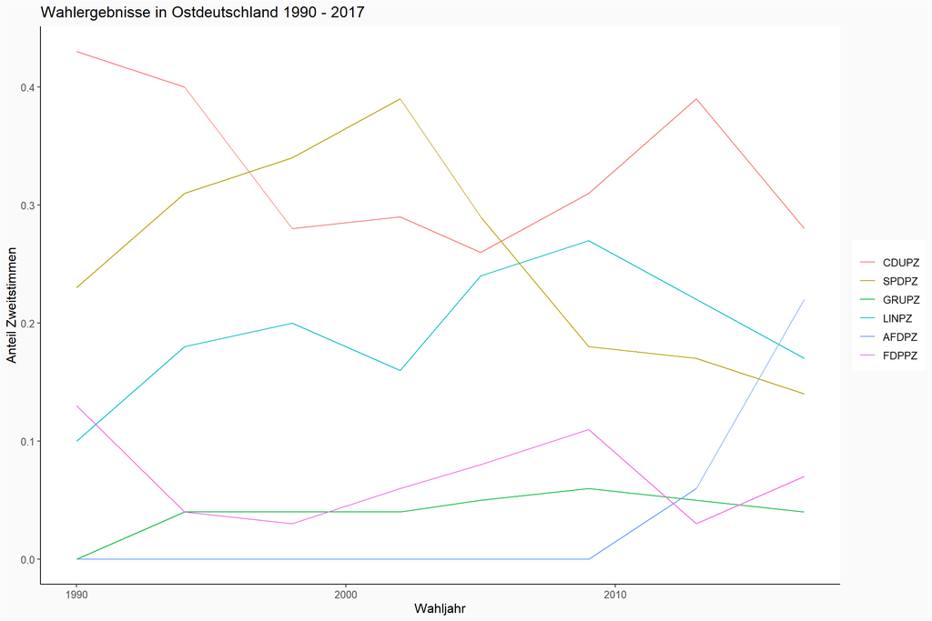

```r
# Visualisierung der Daten mit Hilfe einen Liniendiagramms
ggplot(ostwahl, aes(x=Wahljahr, y=value, color=variable)) +
  geom_line() +
  theme_classic() +
  expand_limits(y=0) +
  labs(title="Wahlergebnisse in Ostdeutschland 1990 - 2017", x="Wahljahr", y="Anteil Zweitstimmen") +
  theme(text = element_text(size=12),
        plot.background = element_rect(fill = "#FAFAFA"),
        panel.grid.major = element_blank(),
        panel.grid.minor = element_blank(),
        legend.title = element_blank())
```

### 5.3. Auswertung von Strukturdaten

#### Verteilung der durchschnittlichen Bruttoeinkommen in Deutschland (2017)

##### Einlesen der benötigten Strukturdaten

```r
# btw1990 <- ReadMyData("dfin_1990", output)
# btw1990 <- set_utf8(btw1990)
bruttoeinkomm <- read_excel("C:/Weiterbildung/HdM/Projektarbeit/FINAL DATA/StrukTest/struktur_Bruttoeinkommen.xlsx")
head(bruttoeinkomm, 5)
```

```
# A tibble: 5 x 8
  Column1 Bruttoentgelte.~ YearSchluessel  Year Schluessel LAND_NAME
    <dbl> <chr>                     <dbl> <dbl>      <dbl> <chr>
1       1 29.5                  199501001  1995       1001 Schleswi~
2       2 33.3                  199501002  1995       1002 Schleswi~
3       3 29.8                  199501003  1995       1003 Schleswi~
4       4 29                    199501004  1995       1004 Schleswi~
5       5 32.9                  199501051  1995       1051 Schleswi~
# ... with 2 more variables: LAND_ABK <chr>, `Stadt-/Landkreis` <chr>
```

##### Extraktion und Vorbereitung der für die Analyse benötigten Daten

```r
# Extraktion relevanter Daten
bruttoeinkomm2017 <- bruttoeinkomm%>%
  filter(Year=="2017")%>%
  rename("Bruttoentgelte"="Bruttoentgelte.je.Beschäftigten.in.Tsd..EUR")%>%
  filter(Bruttoentgelte != "NA")%>%
  select(-Column1)
bruttoeinkomm2017 <- within(bruttoeinkomm2017, {
        Bruttoentgelte <- as.numeric(as.character(Bruttoentgelte))
})
head(bruttoeinkomm2017, 5)
```

```
# A tibble: 5 x 7
  Bruttoentgelte YearSchluessel  Year Schluessel LAND_NAME LAND_ABK
           <dbl>          <dbl> <dbl>      <dbl> <chr>     <chr>
1           42.8      201701001  2017       1001 Schleswi~ SH
2           57.1      201701002  2017       1002 Schleswi~ SH
3           50        201701003  2017       1003 Schleswi~ SH
4           48.8      201701004  2017       1004 Schleswi~ SH
5           46.7      201701051  2017       1051 Schleswi~ SH
# ... with 1 more variable: `Stadt-/Landkreis` <chr>
```

##### Visualisierung der Datenverteilung

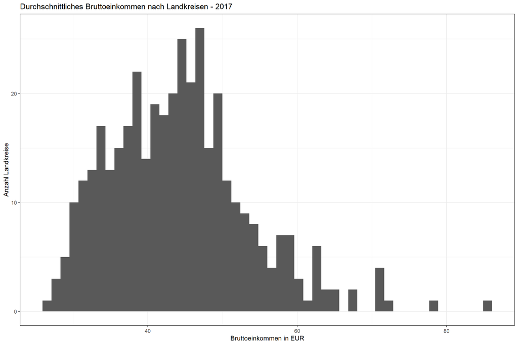

```r
# Visualisierung mit Hilfe eines Histogramms
ggplot(bruttoeinkomm2017, aes(Bruttoentgelte)) +
  geom_histogram(bins = 50) +
  theme_bw() +
  labs(title="Durchschnittliches Bruttoeinkommen nach Landkreisen - 2017", x="Bruttoeinkommen in EUR", y="Anzahl Landkreise")
```

#### Entwicklung der Bruttoeinkommen in Deutschland zwischen 1995 und 2017

Im folgenden soll untersucht werden, ob bereits in der Vergangenheit das oben aufgeführte Verteilungsmuster zu beobachten war. Hierzu müssen zunächst die Daten der entsprechenden Jahre extrahiert werden.

```r
# Aufbereitung der Daten des Jahres 2013
bruttoeinkomm2013 <- bruttoeinkomm%>%
  filter(Year=="2013")%>%
  rename("Bruttoentgelte"="Bruttoentgelte.je.Beschäftigten.in.Tsd..EUR")%>%
  filter(Bruttoentgelte != "NA")%>%
  select(-Column1)
bruttoeinkomm2013 <- within(bruttoeinkomm2013, {
        Bruttoentgelte <- as.numeric(as.character(Bruttoentgelte))
})
head(bruttoeinkomm2013, 5)
```

```
# A tibble: 5 x 7
  Bruttoentgelte YearSchluessel  Year Schluessel LAND_NAME LAND_ABK
           <dbl>          <dbl> <dbl>      <dbl> <chr>     <chr>
1           40.5      201301001  2013       1001 Schleswi~ SH
2           46.3      201301002  2013       1002 Schleswi~ SH
3           42        201301003  2013       1003 Schleswi~ SH
4           46.1      201301004  2013       1004 Schleswi~ SH
5           43        201301051  2013       1051 Schleswi~ SH
# ... with 1 more variable: `Stadt-/Landkreis` <chr>
```

```r
# Aufbereitung der Daten des Jahres 2009
bruttoeinkomm2009 <- bruttoeinkomm%>%
  filter(Year=="2009")%>%
  rename("Bruttoentgelte"="Bruttoentgelte.je.Beschäftigten.in.Tsd..EUR")%>%
  filter(Bruttoentgelte != "NA")%>%
  select(-Column1)
bruttoeinkomm2009 <- within(bruttoeinkomm2009, {
        Bruttoentgelte <- as.numeric(as.character(Bruttoentgelte))
})
head(bruttoeinkomm2009, 5)
```

```
# A tibble: 5 x 7
  Bruttoentgelte YearSchluessel  Year Schluessel LAND_NAME LAND_ABK
           <dbl>          <dbl> <dbl>      <dbl> <chr>     <chr>
1           39.1      200901001  2009       1001 Schleswi~ SH
2           42.7      200901002  2009       1002 Schleswi~ SH
3           38.5      200901003  2009       1003 Schleswi~ SH
4           38.8      200901004  2009       1004 Schleswi~ SH
5           40.3      200901051  2009       1051 Schleswi~ SH
# ... with 1 more variable: `Stadt-/Landkreis` <chr>
```

```r
# Aufbereitung der Daten des Jahres 2005
bruttoeinkomm2005 <- bruttoeinkomm%>%
  filter(Year=="2005")%>%
  rename("Bruttoentgelte"="Bruttoentgelte.je.Beschäftigten.in.Tsd..EUR")%>%
  filter(Bruttoentgelte != "NA")%>%
  select(-Column1)
bruttoeinkomm2005 <- within(bruttoeinkomm2005, {
        Bruttoentgelte <- as.numeric(as.character(Bruttoentgelte))
})
head(bruttoeinkomm2005, 5)
```

```
# A tibble: 5 x 7
  Bruttoentgelte YearSchluessel  Year Schluessel LAND_NAME LAND_ABK
           <dbl>          <dbl> <dbl>      <dbl> <chr>     <chr>
1           36.3      200501001  2005       1001 Schleswi~ SH
2           41.5      200501002  2005       1002 Schleswi~ SH
3           36.9      200501003  2005       1003 Schleswi~ SH
4           34.7      200501004  2005       1004 Schleswi~ SH
5           38.7      200501051  2005       1051 Schleswi~ SH
# ... with 1 more variable: `Stadt-/Landkreis` <chr>
```

```r
# Aufbereitung der Daten des Jahres 2000
bruttoeinkomm2000 <- bruttoeinkomm%>%
  filter(Year=="2000")%>%
  rename("Bruttoentgelte"="Bruttoentgelte.je.Beschäftigten.in.Tsd..EUR")%>%
  filter(Bruttoentgelte != "NA")%>%
  select(-Column1)
bruttoeinkomm2000 <- within(bruttoeinkomm2000, {
        Bruttoentgelte <- as.numeric(as.character(Bruttoentgelte))
})
head(bruttoeinkomm2000, 5)
```

```
# A tibble: 5 x 7
  Bruttoentgelte YearSchluessel  Year Schluessel LAND_NAME LAND_ABK
           <dbl>          <dbl> <dbl>      <dbl> <chr>     <chr>
1           31.7      200001001  2000       1001 Schleswi~ SH
2           36.6      200001002  2000       1002 Schleswi~ SH
3           33.7      200001003  2000       1003 Schleswi~ SH
4           32.4      200001004  2000       1004 Schleswi~ SH
5           36.3      200001051  2000       1051 Schleswi~ SH
# ... with 1 more variable: `Stadt-/Landkreis` <chr>
```

```r
# Aufbereitung der Daten des Jahres 1995
bruttoeinkomm1995 <- bruttoeinkomm%>%
  filter(Year=="1995")%>%
  rename("Bruttoentgelte"="Bruttoentgelte.je.Beschäftigten.in.Tsd..EUR")%>%
  filter(Bruttoentgelte != "NA")%>%
  select(-Column1)
bruttoeinkomm1995 <- within(bruttoeinkomm1995, {
        Bruttoentgelte <- as.numeric(as.character(Bruttoentgelte))
})
head(bruttoeinkomm1995, 5)
```

```
# A tibble: 5 x 7
  Bruttoentgelte YearSchluessel  Year Schluessel LAND_NAME LAND_ABK
           <dbl>          <dbl> <dbl>      <dbl> <chr>     <chr>
1           29.5      199501001  1995       1001 Schleswi~ SH
2           33.3      199501002  1995       1002 Schleswi~ SH
3           29.8      199501003  1995       1003 Schleswi~ SH
4           29        199501004  1995       1004 Schleswi~ SH
5           32.9      199501051  1995       1051 Schleswi~ SH
# ... with 1 more variable: `Stadt-/Landkreis` <chr>
```

##### Erstellen von Histogrammen für die Daten der Jahre 1995, 2000, 2005, 2009, 2013, 2017

```r
# Histogramm für 2017
plot2017 <- ggplot(bruttoeinkomm2017, aes(Bruttoentgelte)) +
  geom_histogram(bins = 50) +
  theme_classic() +
  labs(title="2017", x="Bruttoeinkommen in EUR", y="# LKR")

# Histogramm für 2013
plot2013 <- ggplot(bruttoeinkomm2013, aes(Bruttoentgelte)) +
  geom_histogram(bins = 50) +
  theme_classic() +
  labs(title="2013", x="Bruttoeinkommen in EUR", y="# LKR")

# Histogramm für 2009
plot2009 <- ggplot(bruttoeinkomm2009, aes(Bruttoentgelte)) +
  geom_histogram(bins = 50) +
  theme_classic() +
  labs(title="2009", x="Bruttoeinkommen in EUR", y="# LKR")

# Histogramm für 2005
plot2005 <- ggplot(bruttoeinkomm2005, aes(Bruttoentgelte)) +
  geom_histogram(bins = 50) +
  theme_classic() +
  labs(title="2005", x="Bruttoeinkommen in EUR", y="# LKR")

# Histogramm für 2000
plot2000 <- ggplot(bruttoeinkomm2000, aes(Bruttoentgelte)) +
  geom_histogram(bins = 50) +
  theme_classic() +
  labs(title="2000", x="Bruttoeinkommen in EUR", y="# LKR")

# Histogramm für 1995
plot1995 <- ggplot(bruttoeinkomm1995, aes(Bruttoentgelte)) +
  geom_histogram(bins = 50) +
  theme_classic() +
  labs(title="1995", x="Bruttoeinkommen in EUR", y="# LKR")
```

##### Anordnen der Histogramme in tabellarischer Form

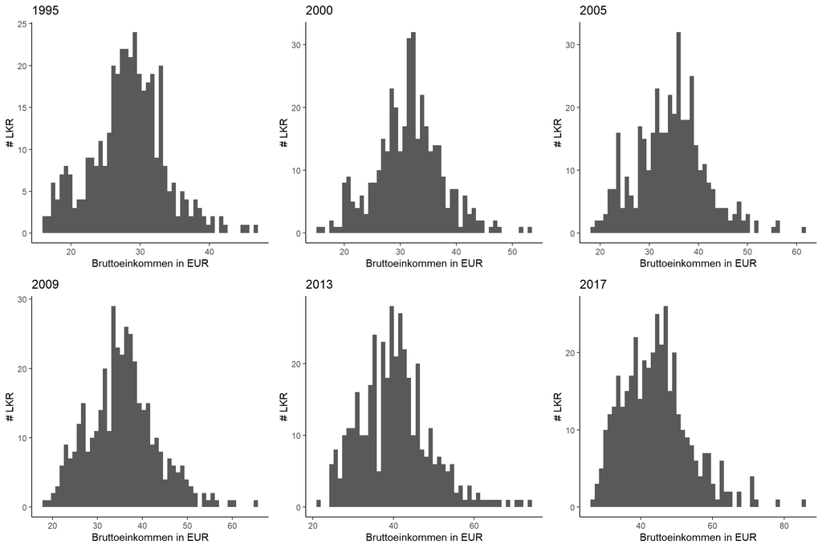

```r
# Tabelle im Format 3 Spalten x 2 Zeilen
require(gridExtra)
grid.arrange(plot1995, plot2000, plot2005, plot2009, plot2013, plot2017, ncol=3)
```

##### Interpretation

In den Jahren von 1995 bis 2009 weisen die Verteilungsmuster der durchschnittlichen Bruttoeinkommen nach Landkreisen eine deutliche **Tendenz zur Normalverteilung** auf. Eine **leicht rechtsschiefe Verteilung ist erst in den Jahren 2013 bzw. 2017** zu erkennen. Dieses deutet darauf hin, dass im laufenden Jahrzehnt die Bruttolöhne sich in einigen wenigen Landkreisen deutlich vom Mittelwert nach oben abgesetzt haben. In den **1990er und 2000er Jahren** sind teilweise noch **Häufungen im untersten Quartil der Verteilung** zu erkennen. Hier ist zu vermuten, dass es sich um Landkreise in Ostdeutschland handelt, die nach der Wiedervereinigung noch deutlich niedrigere Einkommen aufwiesen als westdeutsche Landkreise. Diese Hypothese wird im Folgenden noch näher untersucht.

#### Entwicklung der Bruttoeinkommen im Zeitverlauf München vs. Sachsen-Anhalt

Ergänzend zur Darstellung der Entwicklung im Zeitverlauf mit Hilfe von Histogrammen, soll nun an zwei ausgewählten Gebieten untersucht werden, wie sich die Bruttoeinkommen über die vergangenen 25 Jahre entwickelt haben. Die **Stadt München** wurde beispielhaft ausgewählt als eine Großstadt in Westdeutschland, die sich in den letzten Jahrzehnten wirtschaftlich sehr dynamisch entwickelt hat. Den Vergleichspunkt bietet das **Land Sachsen-Anhalt**. Ausgewählt wurde es als Beispiel einer eher ländlich geprägten Region in Ostdeutschland, mit deutlichen wirtschaftlichen Herausforderungen.

```r
# Datenselektion und -aufbereitung für München
bruttoeinkomm_M <- bruttoeinkomm%>%
  filter(Schluessel=="9162")%>%
  rename("Bruttoentgelte"="Bruttoentgelte.je.Beschäftigten.in.Tsd..EUR")%>%
  filter(Bruttoentgelte != "NA")%>%
  select(-Column1)
bruttoeinkomm_M <- within(bruttoeinkomm_M, {
        Bruttoentgelte <- as.numeric(as.character(Bruttoentgelte))
})
bruttoeinkomm_M <- bruttoeinkomm_M%>%
  select(Year, Bruttoentgelte, "Stadt-/Landkreis")%>%
  rename("Standort"="Stadt-/Landkreis")
head(bruttoeinkomm_M, 5)
```

```
# A tibble: 5 x 3
   Year Bruttoentgelte Standort
  <dbl>          <dbl> <chr>
1  1995           44.8 München
2  2000           53.3 München
3  2005           61.1 München
4  2009           65.5 München
5  2013           74.1 München
```

```r
# Datenselektion und -aufbereitung für Sachsen-Anhalt. Da sich die Landkreisstrukturen in Sachsen-Anhalt im Betrachtungszeitraum verändert haben, werden die Medianwerte der einzelnen Landkreise als durchschnittliches Bruttoeinkommen für das Land Sachsen-Anhalt genommen.
bruttoeinkomm_ST <- bruttoeinkomm%>%
  filter(LAND_ABK=="ST")%>%
  rename("Bruttoentgelte"="Bruttoentgelte.je.Beschäftigten.in.Tsd..EUR")%>%
  filter(Bruttoentgelte != "NA")%>%
  select(-Column1)
bruttoeinkomm_ST <- within(bruttoeinkomm_ST, {
        Bruttoentgelte <- as.numeric(as.character(Bruttoentgelte))
})
bruttoeinkomm_ST <- bruttoeinkomm_ST%>%
  group_by(Year)%>%
  summarize(median(Bruttoentgelte, Year))%>%
  mutate(Standort = "Sachsen-Anhalt")%>%
  rename("Bruttoentgelte"="median(Bruttoentgelte, Year)")
head(bruttoeinkomm_ST, 5)
```

```
# A tibble: 5 x 3
   Year Bruttoentgelte Standort
  <dbl>          <dbl> <chr>
1  1995           21.6 Sachsen-Anhalt
2  2000           23.1 Sachsen-Anhalt
3  2005           25   Sachsen-Anhalt
4  2009           26.7 Sachsen-Anhalt
5  2013           31.0 Sachsen-Anhalt
```

```r
# Verbindung der beiden Einzeltabellen zu einer Gesamtdatei
bruttoeinkommen_M_ST <- rbind(bruttoeinkomm_M, bruttoeinkomm_ST)
head(bruttoeinkommen_M_ST, 5)
```

```
# A tibble: 5 x 3
   Year Bruttoentgelte Standort
  <dbl>          <dbl> <chr>
1  1995           44.8 München
2  2000           53.3 München
3  2005           61.1 München
4  2009           65.5 München
5  2013           74.1 München
```

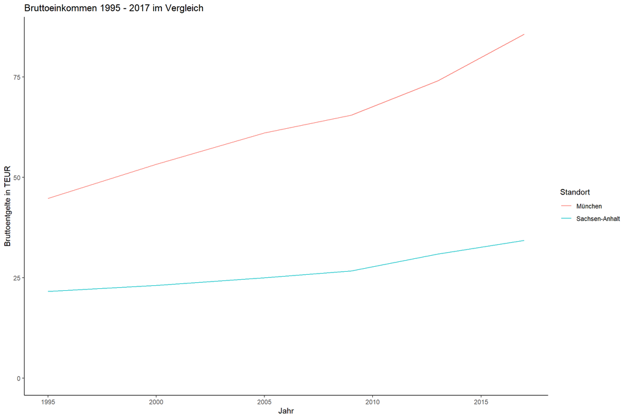

```r
# Visualisierung mit Hilfe eines Liniendiagramms
ggplot(bruttoeinkommen_M_ST, aes(x=Year, y=Bruttoentgelte, color=Standort)) +
  geom_line() +
  theme_classic() +
  expand_limits(y=0) +
  labs(title="Bruttoeinkommen 1995 - 2017 im Vergleich", x="Jahr", y="Bruttoentgelte in TEUR")
```

#### Verfügbares Einkommen - Ost und West im Vergleich

##### Laden der Daten aus der Datenbank

```r
# Laden der Daten
verfeinkomm <- read_excel("C:/Weiterbildung/HdM/Projektarbeit/FINAL DATA/StrukTest/struktur_VerfEinkommen.xlsx")
head(verfeinkomm, 5)
```

```
# A tibble: 5 x 8
  Column1 Verfügbares.Ein~ YearSchluessel  Year Schluessel LAND_NAME
    <dbl> <chr>                     <dbl> <dbl>      <dbl> <chr>
1       1 15596                 200201001  2002       1001 Schleswi~
2       2 15277                 200201002  2002       1002 Schleswi~
3       3 15581                 200201003  2002       1003 Schleswi~
4       4 15599                 200201004  2002       1004 Schleswi~
5       5 15065                 200201051  2002       1051 Schleswi~
# ... with 2 more variables: LAND_ABK <chr>, `Stadt-/Landkreis` <chr>
```

##### Extraktion und Aufbereitung der für die Analyse benötigten Daten

```r
# Extraktion und Aufbereitung der benötigten Daten
verfeinkomm2016 <- verfeinkomm%>%
  filter(Year=="2016")%>%
  rename("Verf_Einkommen"="Verfügbares.Einkommen.je.Einwohner.in.EUR")%>%
  filter(Verf_Einkommen != "NA")%>%
  select(-Column1)%>%
  mutate(OstWest = ifelse(LAND_ABK %in% c("MV", "BB", "SN", "TH", "ST"), "Ost", "West"))
verfeinkomm2016 <- within(verfeinkomm2016, {
        Verf_Einkommen <- as.numeric(as.character(Verf_Einkommen))
})
head(verfeinkomm2016, 5)
```

```
# A tibble: 5 x 8
  Verf_Einkommen YearSchluessel  Year Schluessel LAND_NAME LAND_ABK
           <dbl>          <dbl> <dbl>      <dbl> <chr>     <chr>
1          18481      201601001  2016       1001 Schleswi~ SH
2          18810      201601002  2016       1002 Schleswi~ SH
3          19575      201601003  2016       1003 Schleswi~ SH
4          18922      201601004  2016       1004 Schleswi~ SH
5          21571      201601051  2016       1051 Schleswi~ SH
# ... with 2 more variables: `Stadt-/Landkreis` <chr>, OstWest <chr>
```

##### Visualisierung der Verteilungsmuster

Für die Visualisierung der Verteilungsmuster werden drei separate Datensätze generiert: jeweils ein Datensatz für Ost- und Westdeutschland und einer für Gesamtdeutschland.

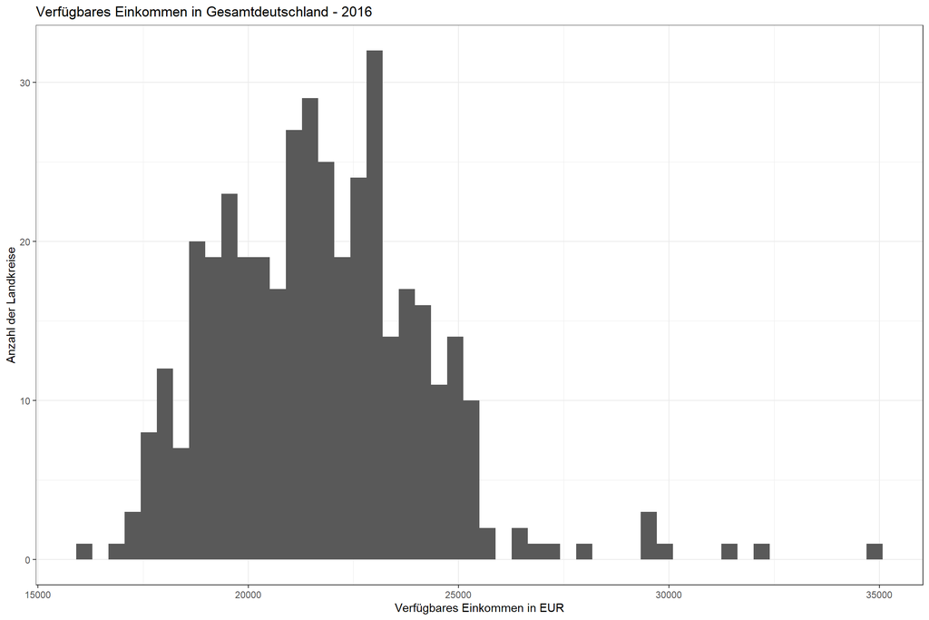

```r
# Visualisierung der Verteilungsmuster in Gesamtdeutschland
ggplot(verfeinkomm2016, aes(Verf_Einkommen)) +
  geom_histogram(bins = 50) +
  theme_bw() +
  labs(title="Verfügbares Einkommen in Gesamtdeutschland - 2016", x="Verfügbares Einkommen in EUR", y="Anzahl der Landkreise")
```

```r
# Visualisierung der Verteilungsmuster in Ostdeutschland
verfeinkomm2016 <- verfeinkomm2016%>%
  mutate(OstWest = ifelse(LAND_ABK %in% c("MV", "BB", "SN", "TH", "ST"), "Ost", "West"))
verfeinkomm2016ost <- filter(verfeinkomm2016, OstWest=="Ost")
head(verfeinkomm2016ost, 5)
```

```
# A tibble: 5 x 8
  Verf_Einkommen YearSchluessel  Year Schluessel LAND_NAME LAND_ABK
           <dbl>          <dbl> <dbl>      <dbl> <chr>     <chr>
1          17609      201612051  2016      12051 Brandenb~ BB
2          19983      201612052  2016      12052 Brandenb~ BB
3          17381      201612053  2016      12053 Brandenb~ BB
4          19550      201612054  2016      12054 Brandenb~ BB
5          19707      201612060  2016      12060 Brandenb~ BB
# ... with 2 more variables: `Stadt-/Landkreis` <chr>, OstWest <chr>
```

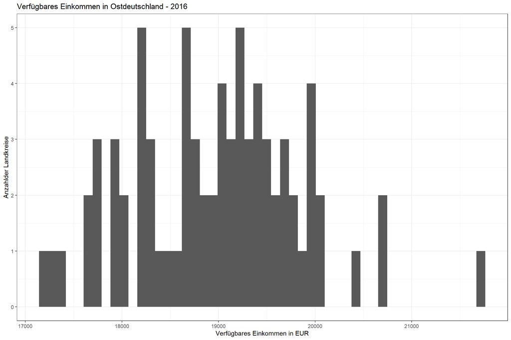

```r
ggplot(verfeinkomm2016ost, aes(Verf_Einkommen)) +
  geom_histogram(bins = 50) +
  theme_bw() +
  labs(title="Verfügbares Einkommen in Ostdeutschland - 2016", x="Verfügbares Einkommen in EUR", y="Anzahlder Landkreise")
```

```r
# Visualisierung der Verteilungsmuster in Westdeutschland
verfeinkomm2016west <- filter(verfeinkomm2016, OstWest=="West")
head(verfeinkomm2016west, 5)
```

```
# A tibble: 5 x 8
  Verf_Einkommen YearSchluessel  Year Schluessel LAND_NAME LAND_ABK
           <dbl>          <dbl> <dbl>      <dbl> <chr>     <chr>
1          18481      201601001  2016       1001 Schleswi~ SH
2          18810      201601002  2016       1002 Schleswi~ SH
3          19575      201601003  2016       1003 Schleswi~ SH
4          18922      201601004  2016       1004 Schleswi~ SH
5          21571      201601051  2016       1051 Schleswi~ SH
# ... with 2 more variables: `Stadt-/Landkreis` <chr>, OstWest <chr>
```

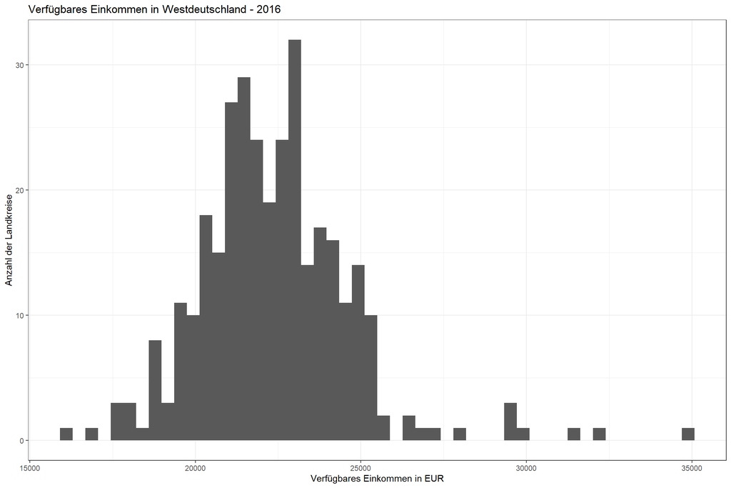

```r
ggplot(verfeinkomm2016west, aes(Verf_Einkommen)) +
  geom_histogram(bins = 50) +
  theme_bw() +
  labs(title="Verfügbares Einkommen in Westdeutschland - 2016", x="Verfügbares Einkommen in EUR", y="Anzahl der Landkreise")
```

##### Interpretation

Alle drei Verteilungsmuster zeigen **ungefähr eine Normalverteilung**. Der Mittelwert liegt bei den westdeutschen Landkreisen etwa bei einem verfügbaren Einkommen von 23.000 EUR. In Ostdeutschland liegt dieser Mittelwert bei rund 19.000 EUR. Für Gesamtdeutschland ergibt sich so ein Mittelwert von ungefähr 21.000 bis 22.000 EUR. Die Ausreißer nach oben werden ausschließlich von westdeutschen Landkreisen beigesteuert.

#### Entwicklung der verfügbaren Einkommen im Zeitverlauf in Ost und West

##### Aufbereitung der Daten für die Jahre 2002 bis 2013

```r
# Daten für 2013 aufbereiten
verfeinkomm2013 <- verfeinkomm%>%
  filter(Year=="2013")%>%
  rename("Verf_Einkommen"="Verfügbares.Einkommen.je.Einwohner.in.EUR")%>%
  filter(Verf_Einkommen != "NA")%>%
  select(-Column1)%>%
  mutate(OstWest = ifelse(LAND_ABK %in% c("MV", "BB", "SN", "TH", "ST"), "Ost", "West"))
verfeinkomm2013 <- within(verfeinkomm2013, {
        Verf_Einkommen <- as.numeric(as.character(Verf_Einkommen))
})
head(verfeinkomm2013, 5)
```

```
# A tibble: 5 x 8
  Verf_Einkommen YearSchluessel  Year Schluessel LAND_NAME LAND_ABK
           <dbl>          <dbl> <dbl>      <dbl> <chr>     <chr>
1          18543      201301001  2013       1001 Schleswi~ SH
2          18429      201301002  2013       1002 Schleswi~ SH
3          18415      201301003  2013       1003 Schleswi~ SH
4          17844      201301004  2013       1004 Schleswi~ SH
5          20267      201301051  2013       1051 Schleswi~ SH
# ... with 2 more variables: `Stadt-/Landkreis` <chr>, OstWest <chr>
```

```r
verfeinkomm2013ost <- filter(verfeinkomm2013, OstWest=="Ost")
verfeinkomm2013west <- filter(verfeinkomm2013, OstWest=="West")

# Daten für 2009 aufbereiten
verfeinkomm2009 <- verfeinkomm%>%
  filter(Year=="2009")%>%
  rename("Verf_Einkommen"="Verfügbares.Einkommen.je.Einwohner.in.EUR")%>%
  filter(Verf_Einkommen != "NA")%>%
  select(-Column1)%>%
  mutate(OstWest = ifelse(LAND_ABK %in% c("MV", "BB", "SN", "TH", "ST"), "Ost", "West"))
verfeinkomm2009 <- within(verfeinkomm2009, {
        Verf_Einkommen <- as.numeric(as.character(Verf_Einkommen))
})
head(verfeinkomm2009, 5)
```

```
# A tibble: 5 x 8
  Verf_Einkommen YearSchluessel  Year Schluessel LAND_NAME LAND_ABK
           <dbl>          <dbl> <dbl>      <dbl> <chr>     <chr>
1          17868      200901001  2009       1001 Schleswi~ SH
2          17062      200901002  2009       1002 Schleswi~ SH
3          17470      200901003  2009       1003 Schleswi~ SH
4          16486      200901004  2009       1004 Schleswi~ SH
5          17821      200901051  2009       1051 Schleswi~ SH
# ... with 2 more variables: `Stadt-/Landkreis` <chr>, OstWest <chr>
```

```r
verfeinkomm2009ost <- filter(verfeinkomm2009, OstWest=="Ost")
verfeinkomm2009west <- filter(verfeinkomm2009, OstWest=="West")

# Daten für 2005 aufbereiten
verfeinkomm2005 <- verfeinkomm%>%
  filter(Year=="2005")%>%
  rename("Verf_Einkommen"="Verfügbares.Einkommen.je.Einwohner.in.EUR")%>%
  filter(Verf_Einkommen != "NA")%>%
  select(-Column1)%>%
  mutate(OstWest = ifelse(LAND_ABK %in% c("MV", "BB", "SN", "TH", "ST"), "Ost", "West"))
verfeinkomm2005 <- within(verfeinkomm2005, {
        Verf_Einkommen <- as.numeric(as.character(Verf_Einkommen))
})
head(verfeinkomm2005, 5)
```

```
# A tibble: 5 x 8
  Verf_Einkommen YearSchluessel  Year Schluessel LAND_NAME LAND_ABK
           <dbl>          <dbl> <dbl>      <dbl> <chr>     <chr>
1          16759      200501001  2005       1001 Schleswi~ SH
2          16249      200501002  2005       1002 Schleswi~ SH
3          17085      200501003  2005       1003 Schleswi~ SH
4          15845      200501004  2005       1004 Schleswi~ SH
5          16567      200501051  2005       1051 Schleswi~ SH
# ... with 2 more variables: `Stadt-/Landkreis` <chr>, OstWest <chr>
```

```r
verfeinkomm2005ost <- filter(verfeinkomm2005, OstWest=="Ost")
verfeinkomm2005west <- filter(verfeinkomm2005, OstWest=="West")

# Daten für 2002 aufbereiten
verfeinkomm2002 <- verfeinkomm%>%
  filter(Year=="2002")%>%
  rename("Verf_Einkommen"="Verfügbares.Einkommen.je.Einwohner.in.EUR")%>%
  filter(Verf_Einkommen != "NA")%>%
  select(-Column1)%>%
  mutate(OstWest = ifelse(LAND_ABK %in% c("MV", "BB", "SN", "TH", "ST"), "Ost", "West"))
verfeinkomm2002 <- within(verfeinkomm2002, {
        Verf_Einkommen <- as.numeric(as.character(Verf_Einkommen))
})
head(verfeinkomm2002, 5)
```

```
# A tibble: 5 x 8
  Verf_Einkommen YearSchluessel  Year Schluessel LAND_NAME LAND_ABK
           <dbl>          <dbl> <dbl>      <dbl> <chr>     <chr>
1          15596      200201001  2002       1001 Schleswi~ SH
2          15277      200201002  2002       1002 Schleswi~ SH
3          15581      200201003  2002       1003 Schleswi~ SH
4          15599      200201004  2002       1004 Schleswi~ SH
5          15065      200201051  2002       1051 Schleswi~ SH
# ... with 2 more variables: `Stadt-/Landkreis` <chr>, OstWest <chr>
```

```r
verfeinkomm2002ost <- filter(verfeinkomm2002, OstWest=="Ost")
verfeinkomm2002west <- filter(verfeinkomm2002, OstWest=="West")
```

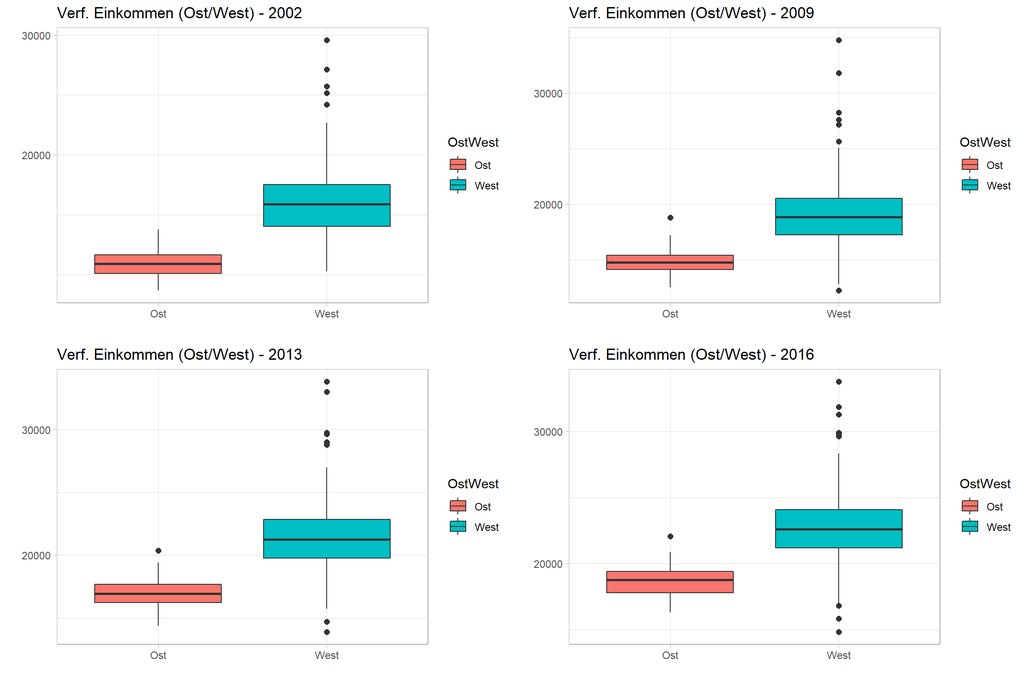

```r
# Boxplot für 2002
plot2002 <- ggplot(verfeinkomm2002, aes(x=OstWest, y=Verf_Einkommen, fill=OstWest)) +
  geom_boxplot(outlier.size=2) +
  theme_light() +
  scale_y_log10() +
  labs(title="Verf. Einkommen (Ost/West) - 2002", x="", y="")

# Boxplot für 2005
plot2005 <- ggplot(verfeinkomm2005, aes(x=OstWest, y=Verf_Einkommen, fill=OstWest)) +
  geom_boxplot(outlier.size=2) +
  theme_light() +
  scale_y_log10() +
  labs(title="Verf. Einkommen (Ost/West) - 2005", x="", y="")

# Boxplot für 2009
plot2009 <- ggplot(verfeinkomm2009, aes(x=OstWest, y=Verf_Einkommen, fill=OstWest)) +
  geom_boxplot(outlier.size=2) +
  theme_light() +
  scale_y_log10() +
  labs(title="Verf. Einkommen (Ost/West) - 2009", x="", y="")

# Boxplot für 2013
plot2013 <- ggplot(verfeinkomm2013, aes(x=OstWest, y=Verf_Einkommen, fill=OstWest)) +
  geom_boxplot(outlier.size=2) +
  theme_light() +
  scale_y_log10() +
  labs(title="Verf. Einkommen (Ost/West) - 2013", x="", y="")

# Boxplot für 2016
plot2016 <- ggplot(verfeinkomm2016, aes(x=OstWest, y=Verf_Einkommen, fill=OstWest)) +
  geom_boxplot(outlier.size=2) +
  theme_light() +
  scale_y_log10() +
  labs(title="Verf. Einkommen (Ost/West) - 2016", x="", y="")

# Anordnen der Boxplots in Tabellenformat
require(gridExtra)
grid.arrange(plot2002, plot2009, plot2013, plot2016, ncol=2)
```

##### Interpretation

Die Boxplots für die Jahre 2002 bis 2016 zeigen deutlich, dass es **im gesamten Beobachtungszeitraum einen deutlichen Unterschied zwischen ost- und westdeutschen Landkreisen** gibt. Der Median der westdeutschen Verteilung liegt im gesamten Zeitraum oberhalt des dritten Quartils der ostdeutschen Werte. Die Boxplots des Jahres 2016 deuten darauf hin, dass sich der Abstand zwischen Ost und West leicht verringert haben könnte, doch ist er nach wie vor deutlich ausgeprägt. Ebenfalls auffällig: **Im Jahre 2002 erkennt man nur wenige Ausreißer** - lediglich einige westdeutsche Landkreise weichen nach oben ab. In den Folgejahren sind verstärkt Ausreißer zu beobachten, in Westdeutschland sogar nach oben und nach unten. **Im Jahre 2016 liegen die unteren Ausreißer in Westdeutschland sogar unterhalb des niedrigsten Wertes in Ostdeutschland.**

#### Darstellung der Entwicklung der verfügbaren Einkommen im Liniendiagramm

```r
# Verbindung der Daten einzelner Jahre zu einer Gesamtdatei
verfeinkommen_all <- rbind(verfeinkomm2002, verfeinkomm2005, verfeinkomm2009, verfeinkomm2013, verfeinkomm2016)
head(verfeinkommen_all, 5)
```

```
# A tibble: 5 x 8
  Verf_Einkommen YearSchluessel  Year Schluessel LAND_NAME LAND_ABK
           <dbl>          <dbl> <dbl>      <dbl> <chr>     <chr>
1          15596      200201001  2002       1001 Schleswi~ SH
2          15277      200201002  2002       1002 Schleswi~ SH
3          15581      200201003  2002       1003 Schleswi~ SH
4          15599      200201004  2002       1004 Schleswi~ SH
5          15065      200201051  2002       1051 Schleswi~ SH
# ... with 2 more variables: `Stadt-/Landkreis` <chr>, OstWest <chr>
```

```r
# Datenaufbereitung - Berechnung der Medianwerte für alle Jahre
verfeinkommen_all <- verfeinkommen_all%>%
  group_by(Year, OstWest)%>%
  summarize(median(Verf_Einkommen, Year))%>%
  rename("Verf_Einkommen"="median(Verf_Einkommen, Year)")
head(verfeinkommen_all, 5)
```

```
# A tibble: 5 x 3
# Groups:   Year [3]
   Year OstWest Verf_Einkommen
  <dbl> <chr>            <dbl>
1  2002 Ost             13833
2  2002 West            16937
3  2005 Ost             14624.
4  2005 West            17920
5  2009 Ost             16176.
```

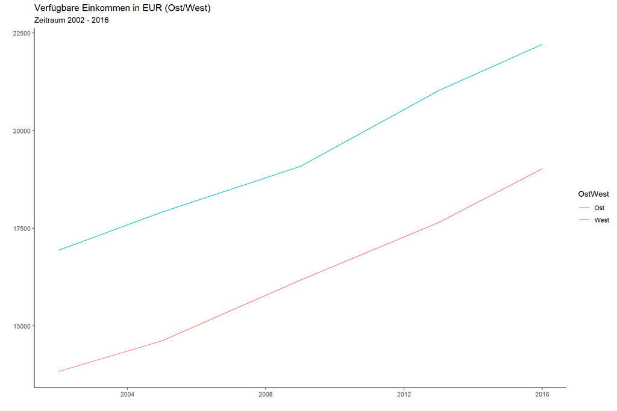

```r
# Visualisierung der Daten im Liniendiagramm
ggplot(verfeinkommen_all, aes(x=Year, y=Verf_Einkommen, color=OstWest)) +
  geom_line() +
  theme_classic() +
  labs(title="Verfügbare Einkommen in EUR (Ost/West)", subtitle="Zeitraum 2002 - 2016", x="", y="")
```

#### Darstellung der Verteilung der verfügbaren Einkommen mit Hilfe eines Schwarmdiagramms

Für diese Form der Darstellung wird ein **Zusatzpaket zu ggplot2 namens ‘beeswarm’** genutzt. Damit lässt sich die Verteilung in einer Art Mischung von Boxplot und Scatterchart aufzeigen. Besonders interessant: Neben der Verteilungsmuster lässt sich eine weitere, binäre Dimension darstellen.

```r
# Verbindung aller Daten in einem Datensatz
verfeinkommen_allbee <- rbind(verfeinkomm2002, verfeinkomm2005, verfeinkomm2009, verfeinkomm2013, verfeinkomm2016)
head(verfeinkommen_allbee, 5)
```

```
# A tibble: 5 x 8
  Verf_Einkommen YearSchluessel  Year Schluessel LAND_NAME LAND_ABK
           <dbl>          <dbl> <dbl>      <dbl> <chr>     <chr>
1          15596      200201001  2002       1001 Schleswi~ SH
2          15277      200201002  2002       1002 Schleswi~ SH
3          15581      200201003  2002       1003 Schleswi~ SH
4          15599      200201004  2002       1004 Schleswi~ SH
5          15065      200201051  2002       1051 Schleswi~ SH
# ... with 2 more variables: `Stadt-/Landkreis` <chr>, OstWest <chr>
```

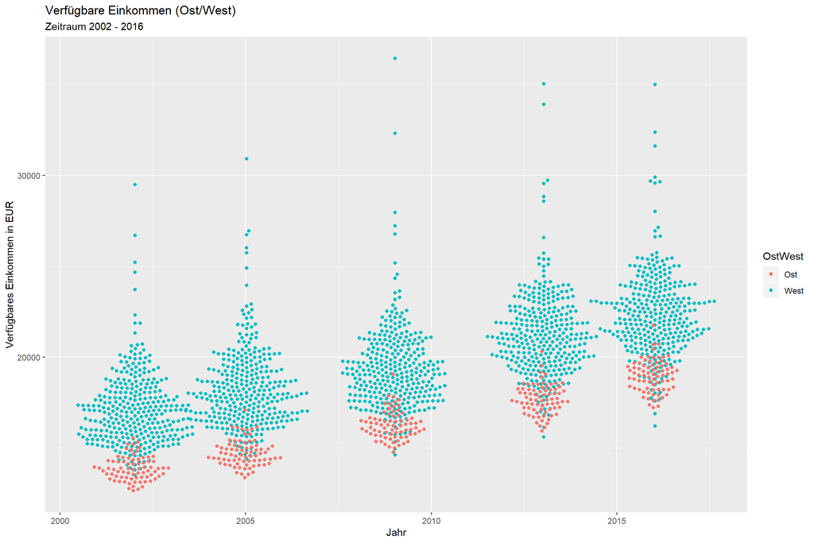

```r
# Visualisierung mit Hilfe eines 'Beeswarm-Charts'
library(ggbeeswarm)
ggplot(verfeinkommen_allbee, aes(x=Year, y=Verf_Einkommen, color=OstWest)) +
  geom_beeswarm(dodge.width=0.1) +
  labs(title="Verfügbare Einkommen (Ost/West)", subtitle="Zeitraum 2002 - 2016", x="Jahr", y="Verfügbares Einkommen in EUR")
```

##### Interpretation

Die Entwicklung der verfügbaren Einkommen in Ost und West lässt sich noch besser mit Hilfe eines Beeswarm-Charts zeigen. Hier entspricht **jeder Punkt im Diagramm einer Beobachtung**. Durch die Farbgebung lässt sich anzeigen, ob es sich um einen ost- oder westdeutschen Landkreis handelt. Sehr schön lässt sich in dieser Darstellung der kontinuierliche Anstieg der verfügbaren Einkommen im Betrachtungszeitraum beobachten. Sehr **deutlich kommt die Zweiteilung zum Ausdruck**. Das untere Drittel der Verteilung wird über den gesamten Zeitraum hinweg von ostdeutschen Landkreise besiedelt. Eine **Vermischung findet im Betrachtungszeit so gut wie nicht statt**. Lediglich in den Jahren 2013 und 2016 brechen drei bis vier ostdeutsche Landkreise nach oben aus. Etwas größer ist die Zahl der westdeutschen Landkreise, die sich nach unten entwickeln. Sehr deutlich zu erkennen ist die **größere Zahl einzelner Landkreise aus Westdeutschland, die Ausreißer nach oben** darstellen.

#### Darstellung der Verteilung der Bruttoeinkommen mit Hilfe eines Schwarmdiagramms

```r
# Vorbereitung der Daten
bruttoeinkommen <- bruttoeinkomm%>%
  rename("Bruttoentgelte"="Bruttoentgelte.je.Beschäftigten.in.Tsd..EUR")%>%
  filter(Bruttoentgelte != "NA")%>%
  select(-Column1)%>%
  mutate(OstWest = ifelse(LAND_ABK %in% c("MV", "BB", "SN", "TH", "ST"), "Ost", "West"))
bruttoeinkommen <- within(bruttoeinkommen, {
        Bruttoentgelte <- as.numeric(as.character(Bruttoentgelte))
})
head(bruttoeinkommen, 5)
```

```
# A tibble: 5 x 8
  Bruttoentgelte YearSchluessel  Year Schluessel LAND_NAME LAND_ABK
           <dbl>          <dbl> <dbl>      <dbl> <chr>     <chr>
1           29.5      199501001  1995       1001 Schleswi~ SH
2           33.3      199501002  1995       1002 Schleswi~ SH
3           29.8      199501003  1995       1003 Schleswi~ SH
4           29        199501004  1995       1004 Schleswi~ SH
5           32.9      199501051  1995       1051 Schleswi~ SH
# ... with 2 more variables: `Stadt-/Landkreis` <chr>, OstWest <chr>
```

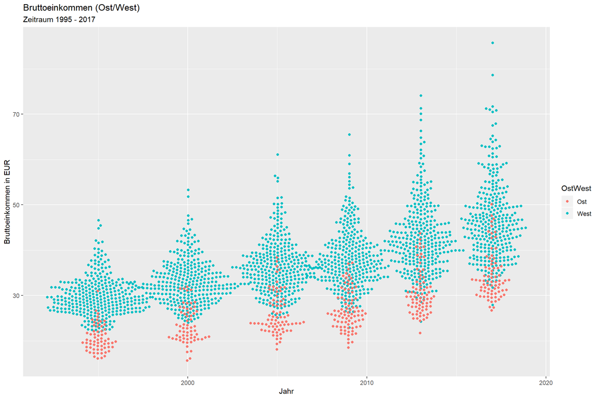

```r
# Visualisierung mit Hilfe eines 'Beeswarm-Charts'
ggplot(bruttoeinkommen, aes(x=Year, y=Bruttoentgelte, color=OstWest)) +
  geom_beeswarm(dodge.width=0.1) +
  labs(title="Bruttoeinkommen (Ost/West)", subtitle="Zeitraum 1995 - 2017", x="Jahr", y="Bruttoeinkommen in EUR")
```

##### Interpretation

Auch für die Darstellung der Entwicklung der Bruttoeinkommen in Ost und West eignet sich das Beeswarm-Chart hervorragend. Das **Grundmuster ist ähnlich wie bei den verfügbaren Einkommen**. Sehr schön lässt sich auch hier der kontinuierliche Anstieg der verfügbaren Einkommen im Betrachtungszeitraum beobachten. Auch hier ist eine klare Zweiteilung zu erkennen - die ostdeutschen Landkreise befinden sich auch hier im unteren Drittel. Allerdings ist **beim Bruttoeinkommen eine höhere Vermischung** zu beobachten. Eine größere Zahl von ostdeutschen Landkreisen zeigen zunehmend Bruttoeinkommen im mittleren Bereich, insbesondere in den 2010er Jahren. Eine weitere Entwicklung, die sich in dieser Darstellung zeigen lässt: Während es beim Bruttoeinkommen **im Jahr 1995 noch kaum Ausreißer nach oben** gab, ist deren **Anzahl vor allem in den vergangenen zehn Jahren deutlich gestiegen**.

### 5.4. Hypothesentests

Mit R lassen sich auf sehr einfache Weise statistische Berechnungen durchführen. Dies soll am Beispiel eines Hypothesentests und einer Korrelationsanalyse weiter vertieft werden.

#### Formulierung der Hypothese

Die **Hypothese ist, dass sowohl im Jahr 1995 als auch im Jahr 2017 die statistischen Unterschiede bei den Bruttoeinkommen in Ost und West nach wie vor statistisch signifikant sind**. Mathematisch kann man das wie folgt ausdrücken:

*H1a: mean_bruttoeinkommen(West-1995) - mean_bruttoeinkommen(Ost-1995) > 0* *H1b: mean_bruttoeinkommen(West-2017) - mean_bruttoeinkommen(Ost-2017) > 0*

Die **Null-Hypothese** ist folglich die Aussage, dass es weder 1995 noch 2017 statistisch signifikante Unterschiede bei den Bruttoeinkommen in Ost und West gab. Mathematisch gesprochen:

*H1a: mean_bruttoeinkommen(West-1995) - mean_bruttoeinkommen(Ost-1995) <= 0* *H1b: mean_bruttoeinkommen(West-2017) - mean_bruttoeinkommen(Ost-2017) <= 0*

Angelegt werden soll bei unserem Test ein **Signifikanzniveau von 0.01**, um die Nullhypothesen zu verwerfen. **Werden beide Varianten der Nullhypothese verworfen, wird die Gesamthypothese als bestätigt gewertet**.

#### Visualisierung der Verteilungsmuster

Zunächst sollen die Verteilungsmuster der Werte aus den Jahren 1995 und 2017 visuell dargestellt werden. Dieses geschieht mit Hilfe von Histogrammen.

```r
# Verteilung der Bruttoeinkommen in Ost und West in den Jahren 1995 und 2017 - Histogramm-Darstellung

bruttoeinkommen1995ost <- bruttoeinkommen%>%
  filter(OstWest=="Ost")%>%
  filter(Year==1995)%>%
  select(Bruttoentgelte)
head(bruttoeinkommen1995ost, 5)
```

```
# A tibble: 5 x 1
  Bruttoentgelte
           <dbl>
1           22.1
2           22.1
3           23.6
4           24.7
5           21.1
```

```r
bruttoeinkommen1995west <- bruttoeinkommen%>%
  filter(OstWest=="West")%>%
  filter(Year==1995)%>%
  select(Bruttoentgelte)
head(bruttoeinkommen1995west, 5)
```

```
# A tibble: 5 x 1
  Bruttoentgelte
           <dbl>
1           29.5
2           33.3
3           29.8
4           29
5           32.9
```

```r
bruttoeinkommen2017ost <- bruttoeinkommen%>%
  filter(OstWest=="Ost")%>%
  filter(Year==2017)%>%
  select(Bruttoentgelte)
head(bruttoeinkommen2017ost, 5)
```

```
# A tibble: 5 x 1
  Bruttoentgelte
           <dbl>
1           43.7
2           46.3
3           32.4
4           33.3
5           31.5
```

```r
bruttoeinkommen2017west <- bruttoeinkommen%>%
  filter(OstWest=="West")%>%
  filter(Year==2017)%>%
  select(Bruttoentgelte)
head(bruttoeinkommen2017west, 5)
```

```
# A tibble: 5 x 1
  Bruttoentgelte
           <dbl>
1           42.8
2           57.1
3           50
4           48.8
5           46.7
```

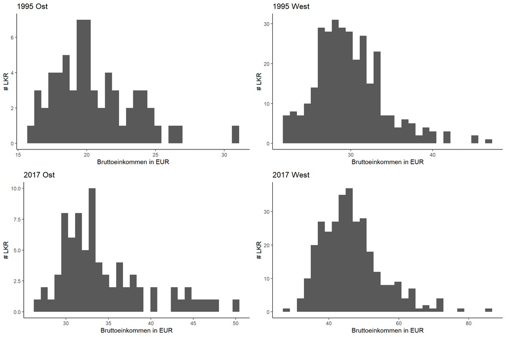

```r
# Erstellen der Histogramme

plot1995ost <- ggplot(bruttoeinkommen1995ost, aes(Bruttoentgelte)) +
  geom_histogram(bins = 30) +
  theme_classic() +
  labs(title="1995 Ost", x="Bruttoeinkommen in EUR", y="# LKR")

plot1995west <- ggplot(bruttoeinkommen1995west, aes(Bruttoentgelte)) +
  geom_histogram(bins = 30) +
  theme_classic() +
  labs(title="1995 West", x="Bruttoeinkommen in EUR", y="# LKR")

plot2017ost <- ggplot(bruttoeinkommen2017ost, aes(Bruttoentgelte)) +
  geom_histogram(bins = 30) +
  theme_classic() +
  labs(title="2017 Ost", x="Bruttoeinkommen in EUR", y="# LKR")

plot2017west <- ggplot(bruttoeinkommen2017west, aes(Bruttoentgelte)) +
  geom_histogram(bins = 30) +
  theme_classic() +
  labs(title="2017 West", x="Bruttoeinkommen in EUR", y="# LKR")

# Anordnung im Tabellenformat
require(gridExtra)
grid.arrange(plot1995ost, plot1995west, plot2017ost, plot2017west, ncol=2)
```

#### Berechnung wichtiger statistischer Kennzahlen

```r
summary(bruttoeinkommen1995ost)
```

```
 Bruttoentgelte
 Min.   :16.10
 1st Qu.:18.55
 Median :19.80
 Mean   :20.53
 3rd Qu.:22.10
 Max.   :31.00
```

```r
summary(bruttoeinkommen1995west)
```

```
 Bruttoentgelte
 Min.   :21.90
 1st Qu.:27.00
 Median :29.30
 Mean   :29.84
 3rd Qu.:32.00
 Max.   :46.60
```

```r
summary(bruttoeinkommen2017ost)
```

```
 Bruttoentgelte
 Min.   :26.70
 1st Qu.:30.88
 Median :33.15
 Mean   :34.45
 3rd Qu.:36.52
 Max.   :50.10
```

```r
summary(bruttoeinkommen2017west)
```

```
 Bruttoentgelte
 Min.   :27.90
 1st Qu.:40.48
 Median :45.50
 Mean   :46.47
 3rd Qu.:50.42
 Max.   :85.70
```

#### Durchführung von t-Tests für die Jahre 1995 und 2017

```r
# t-Test für Daten des Jahres 1995
X1 <- as.vector(bruttoeinkommen1995west$Bruttoentgelte)
Y1 <- as.vector(bruttoeinkommen1995ost$Bruttoentgelte)
t.test(x=X1, y=Y1, alternative = c("two.sided","less",
 "greater"), mu=0, var.equal=F, paired=F, conf.level=0.99)
```

```
    Welch Two Sample t-test

data:  X1 and Y1
t = 21.331, df = 118.78, p-value < 2.2e-16
alternative hypothesis: true difference in means is not equal to 0
99 percent confidence interval:
  8.159174 10.442012
sample estimates:
mean of x mean of y
 29.83551  20.53492
```

```r
# t-Test für Daten des Jahres 2017
X1 <- as.vector(bruttoeinkommen2017west$Bruttoentgelte)
Y1 <- as.vector(bruttoeinkommen2017ost$Bruttoentgelte)
t.test(x=X1, y=Y1, alternative = c("two.sided","less",
 "greater"), mu=0, var.equal=F, paired=F, conf.level=0.99)
```

```
    Welch Two Sample t-test

data:  X1 and Y1
t = 15.546, df = 183.87, p-value < 2.2e-16
alternative hypothesis: true difference in means is not equal to 0
99 percent confidence interval:
 10.00879 14.03424
sample estimates:
mean of x mean of y
 46.47152  34.45000
```

##### Interpretation

Abschließend können wir zusammenfassen, dass die **Gesamthypothese als bestätigt betrachtet werden kann**. Grund: **Sowohl die Nullhypothese H1a für das Jahr 1995 als auch die Nullhypothese H1b für das Jahr 2017 konnten verworfen werden**. Die Unterschiede zwischen beiden Gruppen waren in der Vergangenheit und sind auch heute (i.e. 2017) noch statistisch signifikant.